# Démonstrations R - Module 07

## Question et fichiers

Comment stabiliser une prévision de demande tout en restant sensible aux changements récents? Une équipe d’approvisionnement doit prévoir la demande des treize prochaines semaines. Chaque ligne du fichier représente une semaine fictive et la demande est mesurée en unités de produit. On reprend les 104 semaines du module 06. Le prix et les promotions décrivent le contexte. Les prévisions de cette démonstration utilisent uniquement la demande passée.

Décompressez le projet de départ pour votre travail ou la démonstration complète pour reprendre tous les calculs. Ouvrez le `.Rproj`. Les dictionnaires et fonctions R sont fournis.

## Préparation

Installez une fois `tidyverse`, `slider` et `forecast` si nécessaire, dans la console avec `install.packages(c("tidyverse", "slider", "forecast"))`. Les blocs visibles s’exécutent ensuite dans l’ordre depuis une session R neuve. Le dossier `R/` contient la récurrence `niveau_ses()` et les formules de `mesures_erreurs()`; conservez-le avec `data/`.

```r
library(tidyverse)
library(slider)
library(forecast)

# Ouvrir le projet .Rproj fourni : R/ et data/ sont à côté du rapport.
source("R/fonctions-module07.R")
demande <- read_csv("data/demande_hebdomadaire_quebec.csv",
                    show_col_types = FALSE) |>
  mutate(semaine = as.Date(semaine)) |>
  arrange(semaine)
stopifnot(nrow(demande) == 104L, !anyNA(demande),
          !anyDuplicated(demande$semaine),
          all(diff(demande$semaine) == 7))
horizon <- 13L
apprentissage <- demande |> slice_head(n = 91)
validation <- demande |> slice_tail(n = horizon)
serie <- ts(apprentissage$demande, frequency = 52)
```

La colonne `semaine` donne le lundi qui ouvre chaque semaine. La dernière des 91 semaines d’apprentissage commence le 22 septembre 2025. L’équipe émet les treize prévisions à la fin de cette semaine, avant d’observer la demande de la semaine du 29 septembre.

| Données | Semaines commençant du… au… | Rôle |
| --- | --- | --- |
| Apprentissage | 1er janvier 2024 au 22 septembre 2025 | Calculer les niveaux et ajuster le SES. |
| Validation | 29 septembre au 22 décembre 2025 | Comparer les prévisions aux treize demandes observées ensuite. |

La semaine du 29 septembre est la cible à l’horizon 1. Celle du 22 décembre est la cible à l’horizon 13. Comme le module 06 a déjà examiné ces cibles, la comparaison reste une validation sur une période connue.

## 1. Choisir une fenêtre

Une moyenne mobile arrière de quatre semaines (MM4) donne le même poids à la semaine courante et aux trois précédentes. Par exemple, quatre demandes de 980, 1 020, 1 080 et 1 120 unités donnent une moyenne de $(980+1\,020+1\,080+1\,120)/4=1\,050$ unités. On connaît cette moyenne à la fin de la quatrième semaine.

Dans `slide_dbl()`, `.before = 3` ajoute trois observations avant la courante, ce qui donne une fenêtre de quatre. Pour MM13, on en ajoute douze. L’option `.complete = TRUE` attend que la fenêtre soit complète avant de calculer la moyenne.

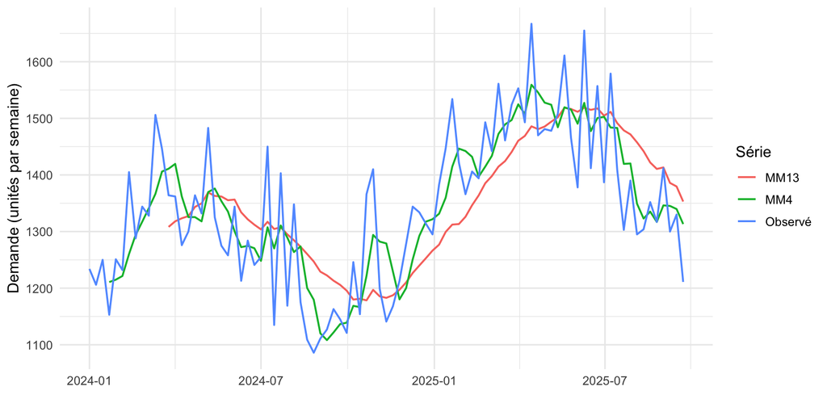

```r
lissage <- apprentissage |>
  mutate(mm4 = slide_dbl(demande, mean, .before = 3, .complete = TRUE),
         mm13 = slide_dbl(demande, mean, .before = 12, .complete = TRUE))
lissage |>
  select(semaine, Observé = demande, MM4 = mm4, MM13 = mm13) |>
  pivot_longer(-semaine, names_to = "serie", values_to = "unites") |>
  ggplot(aes(semaine, unites, colour = serie)) +
  geom_line(linewidth = 0.7, na.rm = TRUE) +
  labs(x = NULL, y = "Demande (unités par semaine)", colour = "Série") +
  theme_minimal(base_size = 12)
```

```r
tail(lissage |> select(semaine, demande, mm4, mm13), 4)
```

```
# A tibble: 4 × 4
  semaine    demande   mm4  mm13
  <date>       <dbl> <dbl> <dbl>
1 2025-09-01    1412 1346. 1413.
2 2025-09-08    1300 1345. 1386.
3 2025-09-15    1330 1340. 1380.
4 2025-09-22    1211 1313. 1353
```

```r
mean(c(980, 1020, 1080, 1120))
```

```
[1] 1050
```

Regardez les dernières semaines du graphique et du tableau. Quand la demande passe de 1 330 à 1 211 unités, les deux moyennes baissent moins que l’observation. MM13 reste plus éloignée de la dernière demande, car sa fenêtre conserve des semaines plus anciennes. Les trois premières valeurs de MM4 et les douze premières de MM13 sont `NA` puisque la fenêtre est encore incomplète. L’option `na.rm = TRUE` évite un avertissement au tracé.

La moyenne arrière $m_t$ contient $y_t$ et devient disponible après cette observation. Elle peut donc servir à prévoir $y_{t+1}$. Une moyenne centrée sur $t$ utilise aussi des observations postérieures à $t$ et sert à décrire la série rétrospectivement. Dans notre comparaison, on répète la dernière MM4 connue à l’origine pour les treize horizons. MM13 sert ici à illustrer l’effet de la largeur de la fenêtre.

## 2. Mettre à jour un niveau

Le lissage exponentiel simple (SES) corrige le niveau précédent d’une fraction $\alpha$ de l’écart avec la nouvelle observation.

$$\ell_t=\ell_{t-1}+\alpha(y_t-\ell_{t-1}).$$

Si le niveau vaut 100 et que la demande passe à 140, l’écart vaut 40. Avec $\alpha=0{,}2$, la correction vaut 8 et le niveau passe à 108. Avec $\alpha=0{,}8$, la correction vaut 32 et le niveau passe à 132. Si la demande reste à 140 la semaine suivante, refaites le calcul à partir de chaque nouveau niveau.

```r
exemple <- tibble(observe = c(100, 100, 140, 140),
                  alpha_02 = niveau_ses(observe, 0.2),
                  alpha_08 = niveau_ses(observe, 0.8))
exemple
```

```
# A tibble: 4 × 3
  observe alpha_02 alpha_08
    <dbl>    <dbl>    <dbl>
1     100     100      100
2     100     100      100
3     140     108      132
4     140     114.     138.
```

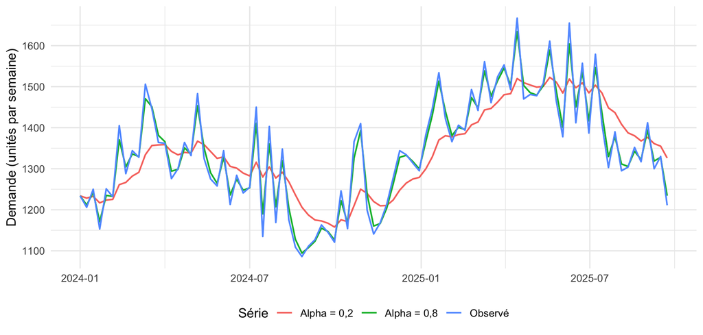

```r
niveaux <- apprentissage |>
  mutate(alpha_02 = niveau_ses(demande, 0.2),
         alpha_08 = niveau_ses(demande, 0.8))
niveaux |>
  select(semaine, Observé = demande, `Alpha = 0,2` = alpha_02,
         `Alpha = 0,8` = alpha_08) |>
  pivot_longer(-semaine, names_to = "serie", values_to = "unites") |>
  ggplot(aes(semaine, unites, colour = serie)) +
  geom_line(linewidth = 0.7) +
  labs(x = NULL, y = "Demande (unités par semaine)", colour = "Série") +
  theme_minimal(base_size = 12) +
  theme(legend.position = "bottom")
```

À la seconde observation de 140, les niveaux atteignent 114,4 et 138,4 unités. Le graphique prolonge la comparaison sur les données d’apprentissage. Les deux courbes partent de la première demande observée. Une valeur élevée d’$\alpha$ donne plus de poids à la dernière observation, qu’il s’agisse d’une variation durable ou d’un pic isolé.

```r
modele_ses <- ses(serie, h = horizon, initial = "optimal")
modele_ses$model$par["alpha"]
```

```
    alpha
0.3711818
```

Pour la comparaison principale, `ses()` estime $\alpha$ et le niveau initial à partir des 91 semaines d’apprentissage. Ici, l’estimation d’$\alpha$ vaut environ 0,371. Les deux valeurs imposées servaient à illustrer la réactivité. À l’origine choisie, le SES répète son dernier niveau aux treize horizons. Il n’extrapole ni pente ni motif saisonnier.

## 3. Émettre et évaluer les prévisions

On compare quatre méthodes à la même origine. Le naïf répète la dernière demande observée, MM4 la moyenne des quatre dernières semaines et SES le dernier niveau estimé. Le naïf saisonnier reprend, pour chaque cible, la demande observée 52 semaines auparavant. Ce cycle de 364 jours approxime le calendrier annuel.

```r
# Dater les cibles à partir du calendrier, puis prévoir avec l’apprentissage.
semaines_cibles <- seq(max(apprentissage$semaine), by = "week",
                      length.out = horizon + 1L)[-1L]
previsions <- tibble(
  semaine = semaines_cibles,
  h = seq_len(horizon),
  Naive = rep(tail(apprentissage$demande, 1), horizon),
  MM4 = rep(tail(lissage$mm4, 1), horizon),
  SES = as.numeric(modele_ses$mean),
  Saisonnier = as.numeric(snaive(serie, h = horizon)$mean)
)
head(previsions, 3)
```

```
# A tibble: 3 × 6
  semaine        h Naive   MM4   SES Saisonnier
  <date>     <int> <dbl> <dbl> <dbl>      <dbl>
1 2025-09-29     1  1211 1313. 1290.       1121
2 2025-10-06     2  1211 1313. 1290.       1246
3 2025-10-13     3  1211 1313. 1290.       1154
```

Chaque ligne contient les quatre prévisions émises pour une même semaine. Les trois premières lignes suffisent pour voir quelles méthodes donnent une prévision constante. Pour mesurer l’erreur, on associe ensuite chaque prévision à l’observation de la même semaine. Une erreur positive indique une sous-prévision. La ME conserve le signe, la MAE mesure l’écart absolu moyen et la RMSE donne plus de poids aux grandes erreurs.

```r
stopifnot(nrow(previsions) == nrow(validation),
          all(previsions$semaine == validation$semaine))
erreurs <- previsions |>
  mutate(observe = validation$demande) |>
  pivot_longer(Naive:Saisonnier, names_to = "methode", values_to = "prevision") |>
  mutate(erreur = observe - prevision)
scores <- erreurs |>
  group_by(methode) |>
  group_modify(~ mesures_erreurs(.x$observe, .x$prevision)) |>
  ungroup() |>
  arrange(MAE)
knitr::kable(scores |> select(methode, ME, MAE, RMSE), digits = 1,
             col.names = c("Méthode", "ME", "MAE", "RMSE"),
             format.args = list(decimal.mark = ","),
             caption = "Erreurs sur les treize semaines, en unités de produit")
```

Erreurs sur les treize semaines, en unités de produit

| Méthode | ME | MAE | RMSE |
| --- | --- | --- | --- |
| MM4 | 82,6 | 100,1 | 128,1 |
| SES | 106,1 | 113,9 | 144,4 |
| Saisonnier | 142,9 | 178,6 | 193,6 |
| Naive | 184,8 | 184,8 | 209,2 |

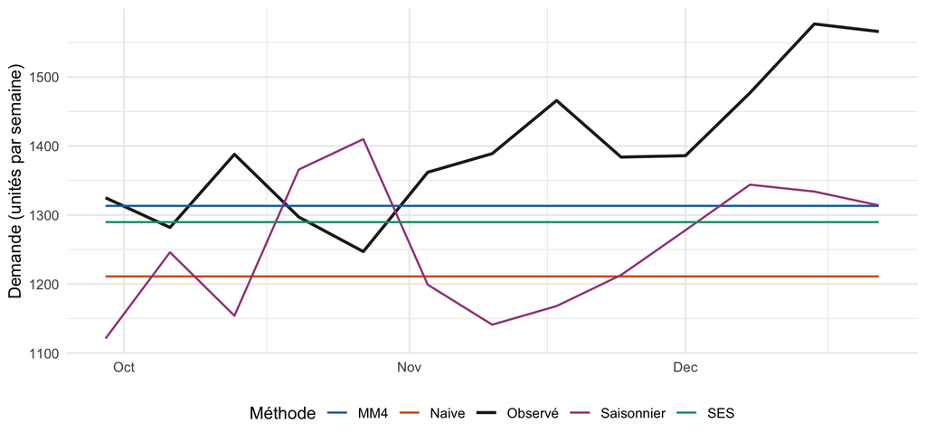

```r
ggplot() +
  geom_line(data = validation, aes(semaine, demande, colour = "Observé"),
            linewidth = 1) +
  geom_line(data = erreurs, aes(semaine, prevision, colour = methode),
            linewidth = 0.7) +
  labs(x = NULL, y = "Demande (unités par semaine)", colour = "Méthode") +
  scale_colour_manual(values = c("Observé" = "#202124", MM4 = "#0072B2",
                                  Naive = "#D55E00", SES = "#009E73",
                                  Saisonnier = "#A34788")) +
  theme_minimal(base_size = 12) +
  theme(legend.position = "bottom")
```

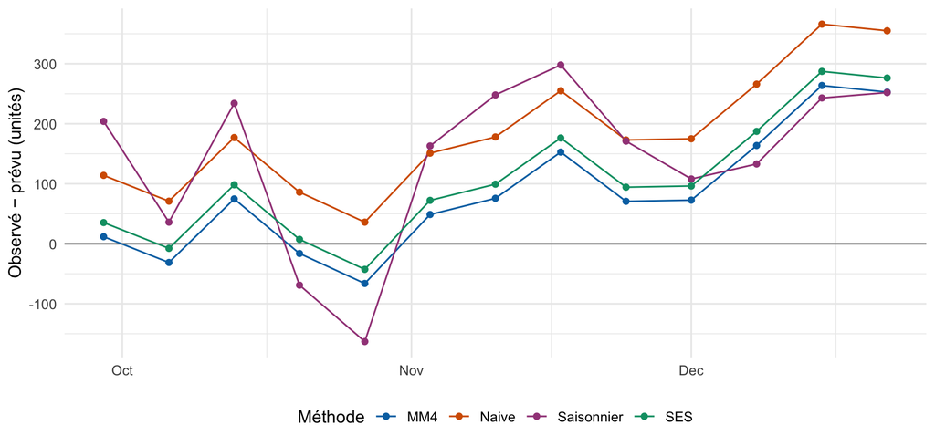

```r
ggplot(erreurs, aes(semaine, erreur, colour = methode)) +
  geom_hline(yintercept = 0, colour = "grey55") +
  geom_line() + geom_point() +
  labs(x = NULL, y = "Observé − prévu (unités)", colour = "Méthode") +
  scale_colour_manual(values = c(MM4 = "#0072B2", Naive = "#D55E00",
                                  SES = "#009E73", Saisonnier = "#A34788")) +
  theme_minimal(base_size = 12) +
  theme(legend.position = "bottom")
```

MM4 a la plus petite MAE sur ces semaines, soit 100,1 unités, et une RMSE de 128,1 unités. Sa ME de +82,6 unités indique une sous-prévision moyenne. Le graphique situe ces écarts dans le temps. Par exemple, la prévision MM4 est trop élevée pour la semaine du 27 octobre, puis reste sous les observations à partir du 3 novembre. Les lectures sur les erreurs reprennent les formules et les limites des mesures.

## 4. Relier le classement à la décision

Supposons qu’une unité sous-prévue coûte deux unités de coût fictives et qu’une unité sur-prévue en coûte une. Une erreur de +10 coûte alors 20, tandis qu’une erreur de −10 coûte 10. On applique la règle à chacune des treize semaines, puis on calcule le coût moyen de chaque méthode.

```r
# Sensibilité hypothétique : une unité sous-prévue coûte 2, une sur-prévue 1.
scores_cout <- erreurs |>
  group_by(methode) |>
  group_modify(~ mesures_erreurs(.x$observe, .x$prevision,
                                cout_sous = 2, cout_sur = 1)) |>
  ungroup() |>
  arrange(cout_moyen)
knitr::kable(scores_cout |> select(methode, MAE, cout_moyen, sous_previsions),
             digits = 1, format.args = list(decimal.mark = ","),
             col.names = c("Méthode", "MAE (unités)", "Coût moyen", "Semaines sous-prévues"),
             caption = "Coût pédagogique moyen par semaine")
```

Coût pédagogique moyen par semaine

| Méthode | MAE (unités) | Coût moyen | Semaines sous-prévues |
| --- | --- | --- | --- |
| MM4 | 100,1 | 191,4 | 10 |
| SES | 113,9 | 223,9 | 11 |
| Saisonnier | 178,6 | 339,4 | 11 |
| Naive | 184,8 | 369,7 | 13 |

Sur cette validation, on peut retenir provisoirement MM4 comme référence. Elle a la plus petite MAE et le plus faible coût moyen dans ce scénario, soit 191,4 unités de coût par semaine. Elle sous-prévoit tout de même la demande pendant 10 des 13 semaines. Pour passer de la prévision à une quantité à commander, l’équipe aurait besoin du stock disponible, des délais et du niveau de service visé.

Pour le suivi, consignez les erreurs et leurs coûts à mesure que les observations arrivent. À une nouvelle origine, comparez de nouveau les quatre méthodes sur les mêmes treize horizons et gardez leurs scores séparés de cette première comparaison.

## Trace finale

Dans `lissage_demande.qmd`, réunissez les productions 7.1 à 7.4, chacune une seule fois. Gardez les périodes d’apprentissage et de validation, les graphiques de lissage, les deux calculs de mise à jour, les prévisions et leurs erreurs, puis la recommandation. Redémarrez R et rendez le rapport pour vérifier que tous les résultats se recalculent. Le transfert sur l’électricité se fait dans un rapport distinct.

## Complément accompagné : Holt

Ce complément est facultatif pour les deux rapports. Si vous le faites, utilisez le code fourni et concentrez-vous sur le rôle du niveau, de la pente et de l’amortissement.

```r
# Facultatif : comparer une tendance amortie, sans composante saisonnière.
modele_holt <- holt(serie, h = horizon, damped = TRUE)
comparaison_holt <- bind_rows(
  scores |> select(methode, ME, MAE, RMSE),
  mesures_erreurs(validation$demande, as.numeric(modele_holt$mean)) |>
    mutate(methode = "Holt amorti") |> select(methode, ME, MAE, RMSE)
)
comparaison_holt |> arrange(MAE)
```

```
# A tibble: 5 × 4
  methode        ME   MAE  RMSE
  <chr>       <dbl> <dbl> <dbl>
1 MM4          82.6  100.  128.
2 SES         106.   114.  144.
3 Holt amorti 152.   152.  189.
4 Saisonnier  143.   179.  194.
5 Naive       185.   185.  209.
```

Holt amorti a une MAE de 152,2 unités sur ces cibles, contre 100,1 pour MM4. Il prolonge une pente dont l’effet diminue avec l’horizon. La pente ne suffit pas à améliorer la MAE dans ce cas. Holt et les modèles qui ajoutent une composante saisonnière sont présentés dans les lectures facultatives.

## Sources et provenance

La série hebdomadaire est simulée pour le cours. Sa provenance et ses variables sont décrites dans les dictionnaires. Pour les méthodes de référence et les mesures, voir Hyndman et Athanasopoulos (2021), [*Forecasting: Principles and Practice*, chapitre 5](https://otexts.com/fpp3/toolbox.html). Pour le SES et Holt, voir le [chapitre 8 du même ouvrage](https://otexts.com/fpp3/exponential-smoothing.html) et la [documentation des fonctions `ses()` et `holt()`](https://pkg.robjhyndman.com/forecast/reference/ses.html).

[IA Assistant IA Ouvrir le GPT du cours](https://chatgpt.com/g/g-6a0b2ec33d948191ad25b2f247b15de1-analyse-et-modelisation-des-donnees?ref=mini)